# COVID19 Report

2023-04-24

# Package Dependencies

To run this R Markdown file, you must have the following packages installed: 1) tidyverse

```r
library('tidyverse')
```

# Introduction

We will be looking at the global COVID-19 data to see if there are any correlations between number of COVID cases versus a country’s population density. We will also look at trends between cases and deaths.

# Data Source

The data was data provided by Johns Hopkins, and can be found here: https://github.com/CSSEGISandData/COVID-19

The data looks a COVID19 cases over time, both in the US and around the world. Specifically, we will evaluate the time series data which uses the following folder path, starting from the downloaded zip file: csse_covid_19_data\csse_covid_19_time_series

And the following files within that folder: 1) time_series_covid19_confirmed_global 2) time_series_covid19_confirmed_US 3) time_series_covid19_deaths_global 4) time_series_covid19_deaths_US

Additionally, we acquired population density data from the following site: https://data.worldbank.org/indicator/EN.POP.DNST

The following csv file was used from the previous site: 1) API_EN.POP.DNST_DS2_en_csv_v2_5358697.csv

# Import the data

```r
file = "time_series_covid19_confirmed_global.csv"
df_confirmed_global = read.csv(file)

file = "time_series_covid19_confirmed_US.csv"
df_confirmed_us = read.csv(file)

file = "time_series_covid19_deaths_global.csv"
df_deaths_global = read.csv(file)

file = "time_series_covid19_deaths_US.csv"
df_deaths_us = read.csv(file)

file = "API_EN.POP.DNST_DS2_en_csv_v2_5358697.csv"
population_density= read.csv(file, skip = 4)
```

# Tidying the data

```r
# Make the global deaths data frame vertical instead of wide
global_deaths = df_deaths_global %>%
  pivot_longer(cols = -c("Province.State", "Country.Region", Lat, Long),
               names_to = "date",
               values_to = "deaths") %>%
  select(-c(Lat, Long))

# Group the deaths data by Country.Region
global_deaths = global_deaths %>%
  group_by(Country.Region, date) %>%
  summarize(total_deaths = sum(deaths))
# Make the global cases data frame vertical instead of wide
global_cases = df_confirmed_global %>%
  pivot_longer(cols = -c("Province.State", "Country.Region", Lat, Long),
               names_to = "date",
               values_to = "cases") %>%
  select(-c(Lat, Long))

# Group the cases data by Country.Region
global_cases = global_cases %>%
  group_by(Country.Region, date) %>%
  summarize(total_cases = sum(cases))
# Merge the global deaths and cases data frames
cases_deaths = merge(global_deaths, global_cases,
               by=c("Country.Region", 'date'))

# Convert date to a better format
cases_deaths = cases_deaths %>%
  mutate(date = sub("X", "", date))
cases_deaths = cases_deaths %>%
  mutate(date = as.Date(date, "%m.%d.%y"))

# Make a summary of global rates
global_rate = cases_deaths %>%
  group_by(date) %>%
  summarize(total_cases = sum(total_cases),
            total_deaths = sum(total_deaths),
            ratio = sum(total_deaths) / sum(total_cases))

# Rename the Country.Name column
names(population_density)[names(population_density) == "Country.Name"] = "Country.Region"

# Use the 2020 population density value
# Note this is the most recent value available at the time
# Note density is number of people per square kilometer
keep = c('Country.Region', 'X2020')
density = subset(population_density, select = keep)

# Summary of cases versus deaths by Country
country_rates = cases_deaths %>%
  group_by(Country.Region) %>%
  summarize(total_cases = sum(total_cases),
            total_deaths = sum(total_deaths),
            ratio = sum(total_deaths) / sum(total_cases))

# Add the population density for each location
density_rate = merge(country_rates, density,
                     by = "Country.Region")
```

In the above code we combined the different global data sets into data frames. We also transformed the date column into an actual date format. Additionally we combined some of the data sets to aid in the following graphing and modeling.

# Graphical Analysis

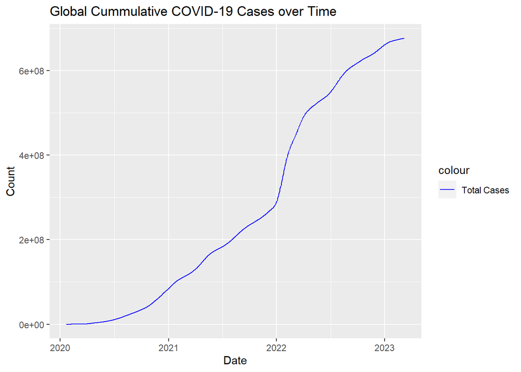

```r
# Plot the number of deaths versus cases over time
p1 = ggplot(global_rate, aes(x = date)) +
  geom_line(aes(y = total_cases, color = "Total Cases")) +
  scale_color_manual(values = c("Total Cases" = "blue")) +
  xlab("Date") +
  ylab("Count") +
  ggtitle("Global Cummulative COVID-19 Cases over Time")

p2 = ggplot(global_rate, aes(x = date)) +
  geom_line(aes(y = total_deaths, color = "Total Deaths")) +
  scale_color_manual(values = c("Total Deaths" = "red")) +
  xlab("Date") +
  ylab("Count") +
  ggtitle("Global Cummulative COVID-19 Deaths over time")

p3 = ggplot(global_rate, aes(x = date)) +
  geom_line(aes(y = ratio, color = "Ratio: Deaths/Cases")) +
  scale_color_manual(values = c("Ratio: Deaths/Cases" = "black")) +
  xlab("Date") +
  ylab("Deaths per Case") +
  ylim(0, NA) +
  ggtitle("Global COVID-19 Deaths per Cases over time")

p1
```

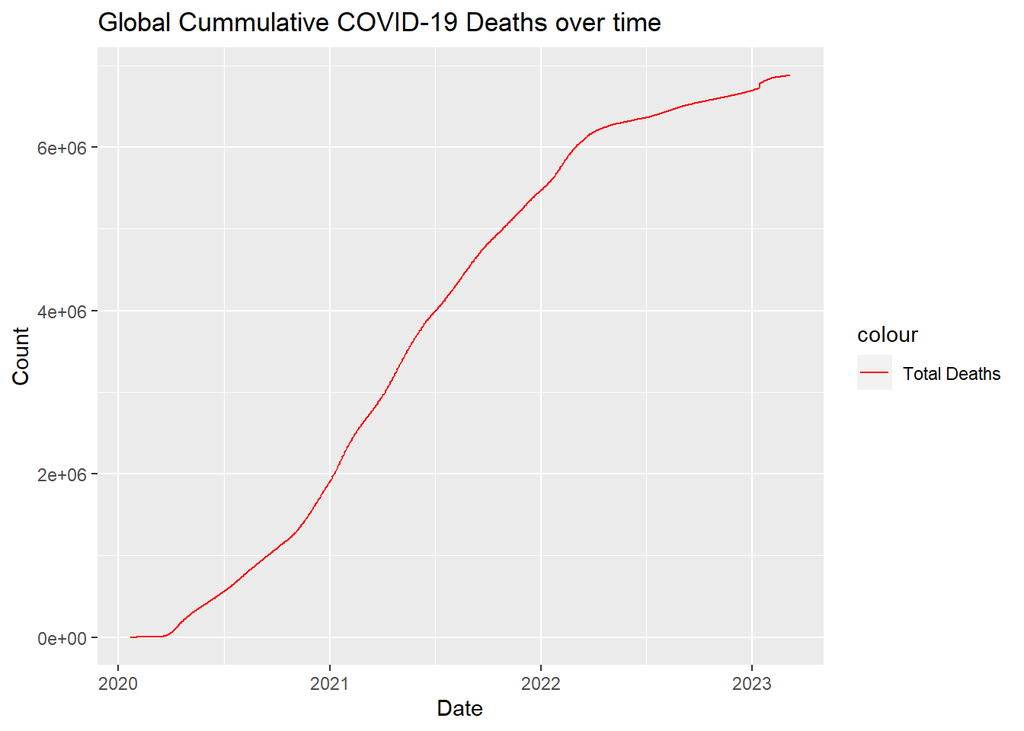

```r
p2
```

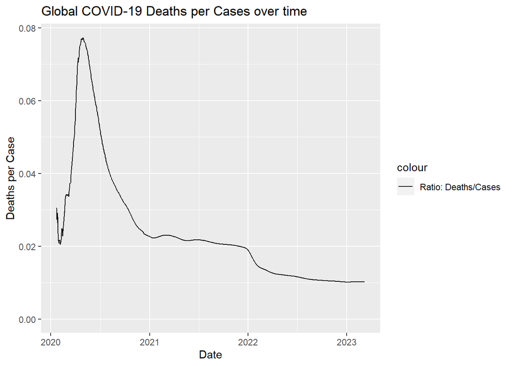

```r
p3
```

# Modeling

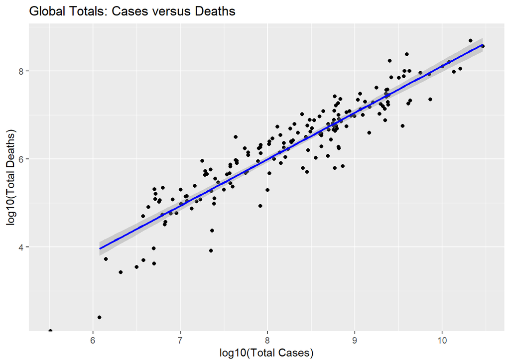

```r
# Number of cases versus number of deaths
ggplot(density_rate, aes(x = log10(total_cases), y = log10(total_deaths))) +
  geom_point() +
  geom_smooth(method = "lm", color = "blue") +
  xlab("log10(Total Cases)") +
  ylab("log10(Total Deaths)") +
  ggtitle("Global Totals: Cases versus Deaths")
```

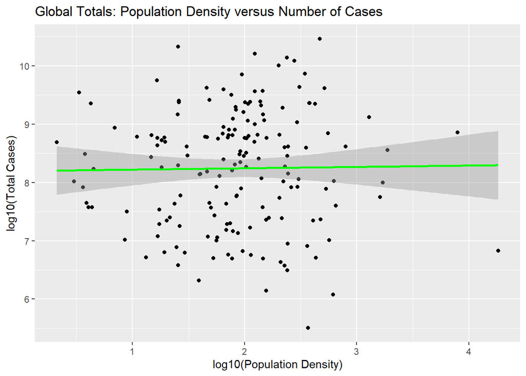

```r
# Number of deaths versus population density
ggplot(density_rate, aes(x = log10(X2020), y = log10(total_cases))) +
  geom_point() +
  geom_smooth(method = "lm", color = "green") +
  xlab("log10(Population Density)") +
  ylab("log10(Total Cases)") +
  ggtitle("Global Totals: Population Density versus Number of Cases")
```

The following graphs look at the total number of cases and deaths from the collected data. To make the graphs easier to read, we looked at the log base 10 values of both total cases and total deaths. Each point on the graph represents a country. It’s quite evident that there is a strong correlation to the number of deaths versus number of cases and it appears to follow a linear model.

However, if we recall from one of the ratio of deaths to cases over time, we noted the number of deaths per case decreased over time. It would be interesting to generate this model on an annual basis to see if the linear trend holds.

We also gathered population density information for each country and used the most recent data that was available at the time (2020). In this data set, we have the number of people per square kilometer of land of each country. In the second graph, we again use the log base 10 scale on both the X-axis (Population Density) and Y-axis (Total Cases). Here we see that the population density does not appear to be correlated with the total number of cases in a country. This could be because of the transmission rate of the COVID-19 virus. Since it is highly infectious, it is able to be transmitted regardless of the different population densities of the countries. If the virus was less transmissible, we would expect to see a lower number of cases in countries with a lower population density.

# Potential Biases

The data we looked at is public information that is based off the data that is reported by different government bodies. Some countries may have inaccurate data or falsified/omitted data that could result in improper conclusions.

Some of the analysis done with population density could be improved by modeling it against the number of cases per population of the country. Another option would be to model the data on an annual or seasonal basis as the rate of infection varies as the population is given vaccinations and recovers from infections.

# Conclusions

From this data the clearest conclusion is the strong positive correlation between number of cases and the number of deaths. Taking these findings we could look into the affects that certain regulations like masking, lock downs, and social-distancing had on the spread of the virus. A good subject for this study would be to look at the US and each state, as each had highly varied approaches to the pandemic. Identifying which efforts are most and least effective would be beneficial during the next pandemic we face.